# Data Analysis and Linear Models Homework 7

### 8.6

```
##        Y               X
##  Min.   : 1.40   Min.   : 8.00
##  1st Qu.:12.30   1st Qu.:11.50
##  Median :20.40   Median :16.00
##  Mean   :17.64   Mean   :15.78
##  3rd Qu.:22.45   3rd Qu.:20.00
##  Max.   :27.10   Max.   :25.00
```

#### a)Fit regression model(8.2)

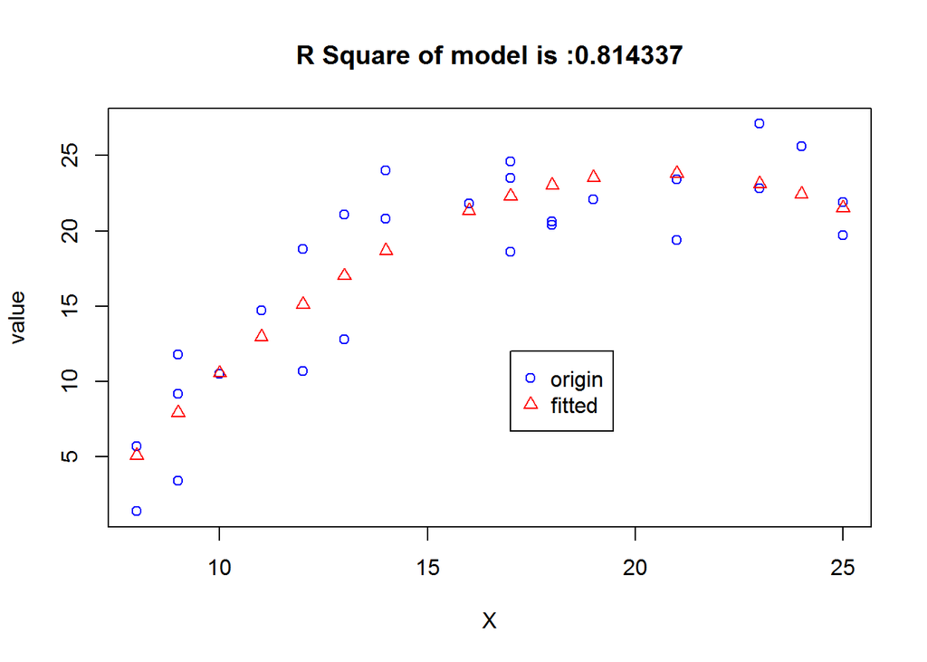

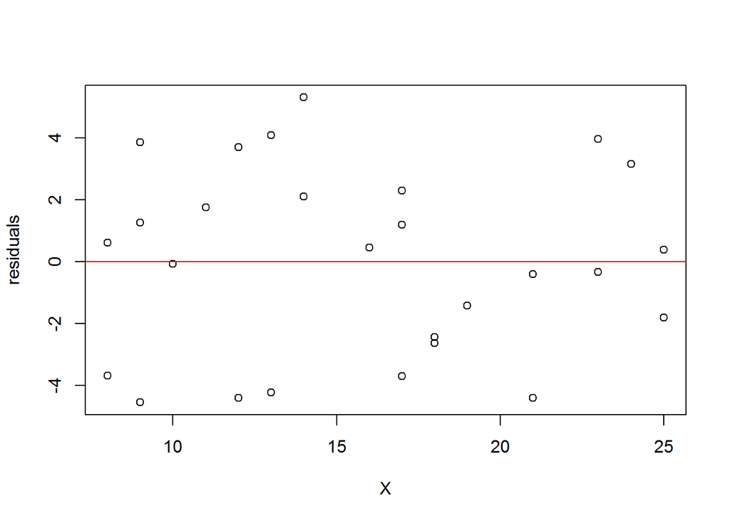

```
## Analysis of Variance Table
##
## Model 1: Y ~ 1
## Model 2: Y ~ X + I(X^2)
##   Res.Df     RSS Df Sum of Sq      F    Pr(>F)
## 1     26 1284.81
## 2     24  238.54  2    1046.3 52.633 1.678e-09 ***
## ---
## Signif. codes:  0 '***' 0.001 '**' 0.01 '*' 0.05 '.' 0.1 ' ' 1
```

The plots *residuals* against linear predictor *X* show us that,The residual is evenly distributed around 0.And the F test of good of fitness in the variable table,the *p-value* is smaller than 0.05,which indicates that the full model is accepted,that is this model is work well;and R Square of the *model.1* is 0.8143372.Based on the two result,which indicats that this model fits well,that is,it is a good fit.

#### b)

To test wether or not there is a regression realation,that is to test the coefficient of quadratic interm is 0:

- H0: beta2 is 0
- H1: beta2 is not 0

```
## [1] "The computed F value is :25.453290"
```

```
## [1] "The computed p value is :0.000037"
```

According to the test above,we know that,the *p-value* is smaller than 0.01,so,we can conclude that,we have 99% confidence to reject the null hypothesis,that is ,the coefficient of quadratic item is not equal to 0.

#### c)

- Confidence intervals(CI)

Use the *Bonferroni Method*,We can get the confidence interval respetively when age=10,15,20,and the confidence intevel at 99 percenpt is (7.6742863,13.4661274),(18.1405546,22.1352916),(21.275656,26.295498)

#### d)

The prediction of model when age=15 is 20.1379231,and the 99% confidence of the prediction intervals is (11.1550164,29.1208298)

#### e)

- H0: beta2 is 0
- H1: beta2 is not 0

#### f)

```
##
## Call:
## lm(formula = Y ~ X + I(X^2), data = Steroid)
##
## Residuals:
##     Min      1Q  Median      3Q     Max
## -4.5463 -2.5369  0.3868  2.1973  5.3020
##
## Coefficients:
##              Estimate Std. Error t value Pr(>|t|)
## (Intercept) -26.32541    5.88154  -4.476 0.000157 ***
## X             4.87357    0.77515   6.287 1.69e-06 ***
## I(X^2)       -0.11840    0.02347  -5.045 3.71e-05 ***
## ---
## Signif. codes:  0 '***' 0.001 '**' 0.01 '*' 0.05 '.' 0.1 ' ' 1
##
## Residual standard error: 3.153 on 24 degrees of freedom
## Multiple R-squared:  0.8143, Adjusted R-squared:  0.7989
## F-statistic: 52.63 on 2 and 24 DF,  p-value: 1.678e-09
```

According to the model,the cofficients of *Intercept* is -26.3254125,cofficients of *X* is 4.8735744,cofficients of *X^2* is -0.1184012,

so the fitted funtion is :Y=-26.3254125*Intercept+4.8735744]*X+-0.1184012*X^2

### 8.21

According to what the topic mean,the linear regression equation is

- Y=b0+b1*X1+b2*X2+b3*X3+bias

#### a)

Develop the response function for each type of protection category:

- When X2=1,X3=0,that is when type of protection is *Hard hat*, and Y=b0+b1*X1+b2
- When X2=0,X3=1,taht is when type of protection is *Bump cap*,and Y=b0+b1*X1+b3
- When X2=0,X3=0,that is when type of protection is *None*,and Y=b0+b1*X1

#### b)

For each of following questions,the alternatives H0 and H1 for the appropriate is :

##### (1)

- H0: b2 is equal to 0
- H1: b2 is smaller than 0

##### (2)

- H0: b2 is equal to b3
- H1: b2 is not equal to b3

### 8.23

I do not agree with the interpretaion with result.Of course,accoding to the test in the result show for us,it just only tells *Winter* has no influence on sale except other interaction with other season.It is only true in this test.Hower,in other test,eg B2=0 or B3=0 or B0=0,they are ignored and not to be condidered in the topic.Besides,and interaction are also not be considered I think.So,I think the interpretion is biased.

### 8.34

#### a)

First-order linear regression model is :

- Y=b0+b1*X1+b2*X2+b3*X3+bias

#### b)

The response functions for the three types of banks:

- When X2=1,X3=0,that is when type of bank is *Commercial*,Y=b0+b1*X1+b2
- When X2=0,X3=1,that is when type of bank is *Mutual saving*,Y=b0+b1*X1+b3
- When X2=-1,X3=-1,that is when type of bank is *Saving and loan*,Y=b0+b1*X1-b2-b3

#### c)

##### (1)

- **b2** means if controlling for X1,when type of bank is *Commercial*,the constant term will increase by **b2** units

##### (2)

- **b3** means if controlling for X1,when type of bank is *Mutual saving*,the constant term will increase by **b3** units

##### (3)

- **-b2-b3** means if controlling for X1,when type of bank is *Saving and loan* ,the constant term will increase by **-b2-b3** units

### 8.39

```
## 'data.frame':    440 obs. of  17 variables:
##  $ Identification.number     : int  1 2 3 4 5 6 7 8 9 10 ...
##  $ County                    : Factor w/ 373 levels "Ada","Adams",..: 179 77 130 284 237 159 190 353 80 82 ...
##  $ State                     : Factor w/ 48 levels "AL","AR","AZ",..: 4 13 42 4 4 33 3 21 9 42 ...
##  $ Land.area                 : int  4060 946 1729 4205 790 71 9204 614 1945 880 ...
##  $ Total.population          : int  8863164 5105067 2818199 2498016 2410556 2300664 2122101 2111687 1937094 1852810 ...
##  $ Percent.of.population18_34: num  32.1 29.2 31.3 33.5 32.6 28.3 29.2 27.4 27.1 32.6 ...
##  $ Percent.of.population65   : num  9.7 12.4 7.1 10.9 9.2 12.4 12.5 12.5 13.9 8.2 ...
##  $ Num.active.physicians     : int  23677 15153 7553 5905 6062 4861 4320 3823 6274 4718 ...
##  $ Num.hospital.beds         : int  27700 21550 12449 6179 6369 8942 6104 9490 8840 6934 ...
##  $ Total.serious.crimes      : int  688936 436936 253526 173821 144524 680966 177593 193978 244725 214258 ...
##  $ Percent.high              : num  70 73.4 74.9 81.9 81.2 63.7 81.5 70 65 77.1 ...
##  $ Percent.bachelor          : num  22.3 22.8 25.4 25.3 27.8 16.6 22.1 13.7 18.8 26.3 ...
##  $ Percent.below             : num  11.6 11.1 12.5 8.1 5.2 19.5 8.8 16.9 14.2 10.4 ...
##  $ Percent.unemploy          : num  8 7.2 5.7 6.1 4.8 9.5 4.9 10 8.7 6.1 ...
##  $ Per.capita.income         : int  20786 21729 19517 19588 24400 16803 18042 17461 17823 21001 ...
##  $ Total.personal.income     : int  184230 110928 55003 48931 58818 38658 38287 36872 34525 38911 ...
##  $ Geographic.region         : int  4 2 3 4 4 1 4 2 3 3 ...
```

#### a) Fit the model

```
##
## Call:
## lm(formula = Y ~ X1 + X2 + X3 + X4 + X5, data = CDI.Sub)
##
## Residuals:
##     Min      1Q  Median      3Q     Max
## -1866.8  -207.7   -81.5    72.4  3721.7
##
## Coefficients:
##               Estimate Std. Error t value Pr(>|t|)
## (Intercept) -2.075e+02  7.028e+01  -2.952  0.00332 **
## X1           5.515e-04  2.835e-04   1.945  0.05243 .
## X2           1.070e-01  1.325e-02   8.073  6.8e-15 ***
## X3           1.490e+02  8.683e+01   1.716  0.08685 .
## X4           1.455e+02  8.515e+01   1.709  0.08817 .
## X5           1.912e+02  8.003e+01   2.389  0.01731 *
## ---
## Signif. codes:  0 '***' 0.001 '**' 0.01 '*' 0.05 '.' 0.1 ' ' 1
##
## Residual standard error: 566.1 on 434 degrees of freedom
## Multiple R-squared:  0.9011, Adjusted R-squared:  0.8999
## F-statistic: 790.7 on 5 and 434 DF,  p-value: < 2.2e-16
```

#### b)

Accordint to the model above ,we can get the model Y=b0+b1*X1 + b2*X2 +b3*X3+b4*X4+b5*X5, and the cofficients we can also get from the model fitted.

All the premise is if X1 if fixed:

- When X3=1,X4=0,X5=0,and Y=b0+b1*X1+b2*X2+b3
- When X3=0,X4=1,X5=0,and Y=b0+b1*X1+b2*X2+b4
- When X3=0,X4=0,X5=1,and Y=b0+b1*X1+b2*X2+b5

So,**b3-b4** is equal to the difference between north eastern region and north central region.

To examine whether the effect is different ,that is to

- H0: b3-b4 is equal to 0
- H1: b3-b4 is not equal 0

```
## [1] "The p-value of the test is : 0.482334"
```

```
## [1] "The 10 percent confidence interval is :(-126.415817,133.402068)"
```

#### c)

To test whether any geograph effects are present ,that is to test b3=b4=b5=0;we can get

- H0: b3,b4,b5 are all equal to 0
- H1: b3,b5,b5 are nor all equal to 0

```
## [1] "The p-value of test is 0.121032"
```